# Gene signature scoring with UCell

Massimo Andreatta and Santiago J. Carmona

Ludwig Institute for Cancer Research, Lausanne Branch, and Department of Oncology, CHUV and University of Lausanne, Epalinges 1066, Switzerland; and Swiss Institute of Bioinformatics, Lausanne, Switzerland

3 February 2022

#### Package

UCell 1.3.2

# 1 Introduction

In single-cell RNA-seq analysis, gene signature (or “module”) scoring constitutes a simple yet powerful approach to evaluate the strength of biological signals, typically associated to a specific cell type or biological process, in a transcriptome.

UCell is an R package for evaluating gene signatures in single-cell datasets. UCell signature scores, based on the Mann-Whitney U statistic, are robust to dataset size and heterogeneity, and their calculation demands less computing time and memory than other available methods, enabling the processing of large datasets in a few minutes even on machines with limited computing power. UCell can be applied to any single-cell data matrix, and includes functions to directly interact with Seurat objects.

# 2 Installation

Install UCell through BiocManager:

```r
BiocManager::install("UCell")
```

# 3 Quick start

To test your installation, load a small sample dataset and run UCell:

```r
library(UCell)

my.matrix <- UCell::sample.matrix
gene.sets <- list(Tcell_signature = c("CD2","CD3E","CD3D"),
            Myeloid_signature = c("SPI1","FCER1G","CSF1R"))

scores <- ScoreSignatures_UCell(my.matrix, features=gene.sets)
head(scores)
```

```
##                       Tcell_signature_UCell Myeloid_signature_UCell
## L5_ATTTCTGAGGTCGTGA               0.8993333                       0
## L4_TCACTATTCATCTCTA               0.6904444                       0
## L1_TCCTTCTTCTTTACAC               0.5935556                       0
## L5_AAAGTGAAGGCGCTCT               0.6093333                       0
## E2L3_CCTCAGTAGTGCAGGT             0.8508889                       0
## L5_CCCTCTCGTTCTAAGC               0.6562222                       0
```

# 4 Get some testing data

For this demo, we will download a single-cell dataset of lung cancer ([Zilionis et al. (2019) Immunity](https://pubmed.ncbi.nlm.nih.gov/30979687/)) through the [scRNA-seq](https://bioconductor.org/packages/3.15/data/experiment/html/scRNAseq.html) package. This dataset contains >170,000 single cells; for the sake of simplicity, in this demo will we focus on immune cells, according to the annotations by the authors, and downsample to 5000 cells.

```r
library(scRNAseq)

#For this demo, limit the analysis to 5000 immune cells
lung <- ZilionisLungData()

immune <- lung$Used & lung$used_in_NSCLC_immune
lung <- lung[,immune]
lung <- lung[,1:5000]

exp.mat <- Matrix::Matrix(counts(lung),sparse = T)
```

# 5 Define gene signatures

Here we define some simple gene sets based on the “Human Cell Landscape” signatures [Han et al. (2020) Nature](https://www.nature.com/articles/s41586-020-2157-4). You may edit existing signatures, or add new one as elements in a list.

```r
signatures <- list(
    Immune = c("PTPRC"),
    Tcell = c("CD3D","CD3E","CD3G","CD2","TRAC"),
    Bcell = c("MS4A1","CD79A","CD79B","CD19","BANK1"),
    Myeloid = c("CD14","LYZ","CSF1R","FCER1G","SPI1","LCK-"),
    NK = c("KLRD1","NCAM1","NKG7","CD3D-","CD3E-"),
    Plasma_cell = c("IGKC","IGHG3","IGHG1","IGHA1","CD19-")
    )
```

# 6 Run UCell

Run `ScoreSignatures_UCell` and get directly signature scores for all cells

```r
u.scores <- ScoreSignatures_UCell(exp.mat,features=signatures)
u.scores[1:10,1:3]
```

```
##        Immune_UCell Tcell_UCell Bcell_UCell
## bcHTNA    0.4493333   0.0000000  0.00000000
## bcHNVA    0.5900000   0.0000000  0.00000000
## bcALZN    0.6473333   0.0000000  0.00000000
## bcFWBP    0.4156667   0.0000000  0.08446667
## bcBJYE    0.9346667   0.0000000  0.00000000
## bcGSBJ    0.9096667   0.0000000  0.00000000
## bcHQGJ    0.8860000   0.0000000  0.00000000
## bcHKKM    0.8590000   0.1282667  0.00000000
## bcIGQU    0.0000000   0.4175333  0.00000000
## bcDVGG    0.6413333   0.3861333  0.00000000
```

Show the distribution of predicted scores

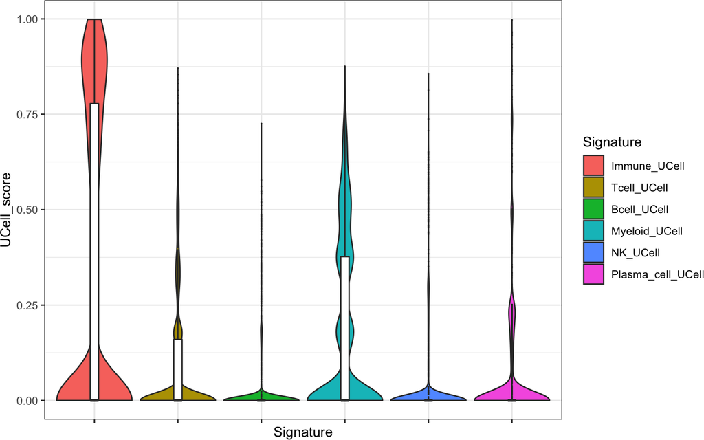

```r
library(reshape2)
library(ggplot2)
melted <- reshape2::melt(u.scores)
colnames(melted) <- c("Cell","Signature","UCell_score")
p <- ggplot(melted, aes(x=Signature, y=UCell_score)) + geom_violin(aes(fill=Signature), scale = "width") +
       geom_boxplot(width=0.1, outlier.size=0) + theme_bw() + theme(axis.text.x=element_blank())
p
```

# 7 Pre-calculating gene rankings

The time- and memory-demanding step in UCell is the calculation of gene rankings for each individual cell. If we plan to experiment with signatures, editing them or adding new cell subtypes, it is possible to pre-calculate the gene rankings once and for all and then apply new signatures over these pre-calculated ranks. Run the `StoreRankings_UCell` function to pre-calculate gene rankings over a dataset:

```r
set.seed(123)
ranks <- StoreRankings_UCell(exp.mat)
ranks[1:5,1:5]
```

```
## 5 x 5 sparse Matrix of class "dgCMatrix"
##           bcHTNA bcHNVA bcALZN bcFWBP bcBJYE
## 5S_rRNA        .      .      .      .      .
## 5_8S_rRNA      .      .      .      .      .
## 7SK            .      .      .      .      .
## A1BG           .      .      .      .      .
## A1BG-AS1       .      .      .      .      .
```

Then, we can apply our signature set, or any other new signature to the pre-calculated ranks. The calculations will be considerably faster.

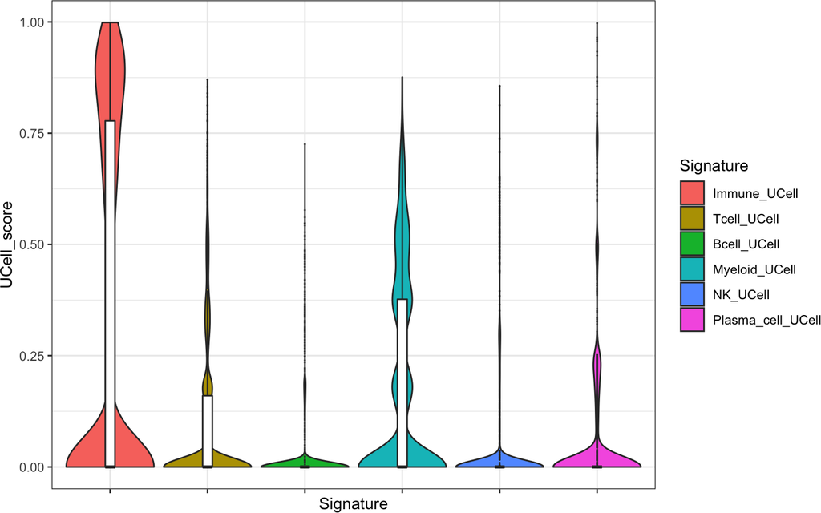

```r
set.seed(123)
u.scores.2 <- ScoreSignatures_UCell(features=signatures, precalc.ranks = ranks)

melted <- reshape2::melt(u.scores.2)
colnames(melted) <- c("Cell","Signature","UCell_score")
p <- ggplot(melted, aes(x=Signature, y=UCell_score)) + geom_violin(aes(fill=Signature), scale = "width") +
       geom_boxplot(width=0.1, outlier.size = 0) + theme_bw() + theme(axis.text.x=element_blank())
p
```

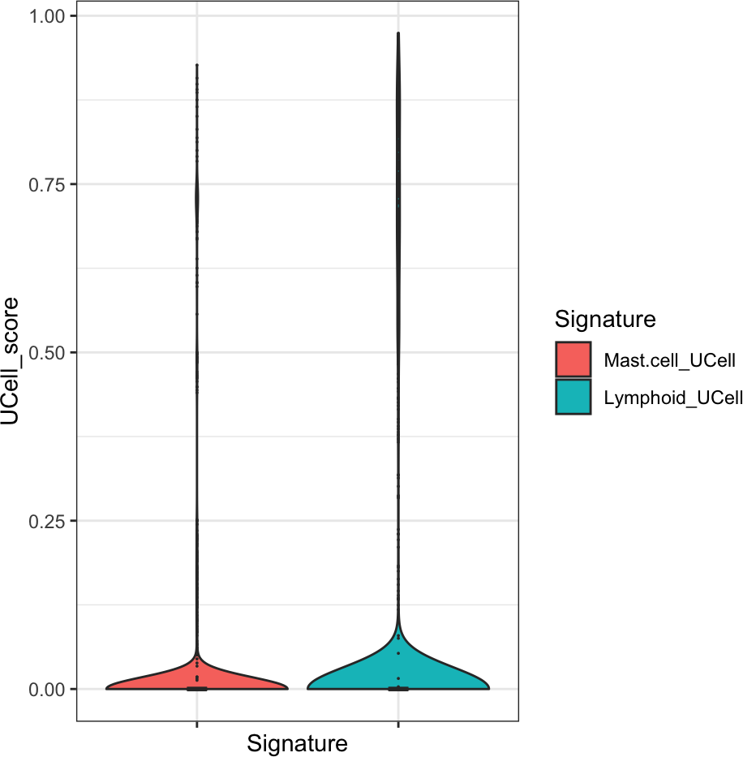

```r
new.signatures <- list(Mast.cell = c("TPSAB1","TPSB2","CPA3","MS4A2"),
                       Lymphoid = c("LCK"))

u.scores.3 <- ScoreSignatures_UCell(features=new.signatures, precalc.ranks = ranks)
melted <- reshape2::melt(u.scores.3)
colnames(melted) <- c("Cell","Signature","UCell_score")
p <- ggplot(melted, aes(x=Signature, y=UCell_score)) + geom_violin(aes(fill=Signature), scale = "width") +
       geom_boxplot(width=0.1, outlier.size=0) + theme_bw() + theme(axis.text.x=element_blank())
p
```

# 8 Multi-core processing

If your machine has multi-core capabilities and enough RAM, running UCell in parallel can speed up considerably your analysis. In this example we will use 4 parallel cores:

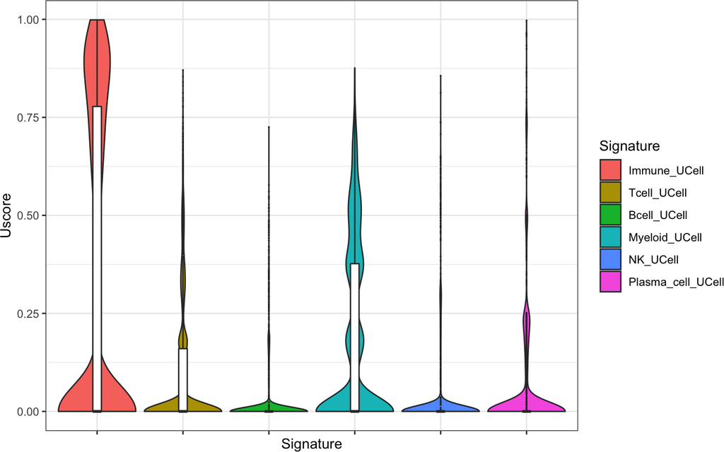

```r
u.scores <- ScoreSignatures_UCell(exp.mat,features=signatures, ncores=4)

melted <- reshape2::melt(u.scores)
colnames(melted) <- c("Cell","Signature","Uscore")
p <- ggplot(melted, aes(x=Signature, y=Uscore)) + geom_violin(aes(fill=Signature), scale = "width") +
       geom_boxplot(width=0.1, outlier.size=0) + theme_bw() + theme(axis.text.x=element_blank())
p
```

# 9 Interacting with SingleCellExperiment or Seurat

[SingleCellExperiment](https://bioconductor.org/packages/release/bioc/html/SingleCellExperiment.html) and [Seurat](https://github.com/satijalab/seurat) are popular environments for single-cell analysis. The UCell package implements functions to interact directly with these pipelines, as described below.

## 9.1 UCell + SingleCellExperiment

The function `ScoreSignatures_UCell_sce()` allows operating directly on `sce` objects. UCell scores are returned in a altExp object (`altExp(sce, 'UCell'`))

```r
library(SingleCellExperiment)

sce <- SingleCellExperiment(list(counts=exp.mat))
sce <- ScoreSignatures_UCell_sce(sce, features=signatures,
                                 assay = 'counts', name=NULL, ncores=4)
altExp(sce, 'UCell')
```

```
## class: SummarizedExperiment
## dim: 6 5000
## metadata(0):
## assays(1): UCell
## rownames(6): Immune Tcell ... NK Plasma_cell
## rowData names(0):
## colnames(5000): bcHTNA bcHNVA ... bcGVZB bcHGKL
## colData names(0):
```

Dimensionality reduction and visualization

```r
library(scater)
library(patchwork)
#PCA
sce <- logNormCounts(sce)
sce <- runPCA(sce, scale=T, ncomponents=20)

#UMAP
set.seed(1234)
sce <- runUMAP(sce, dimred="PCA")
```

Visualize UCell scores on low-dimensional representation (UMAP)

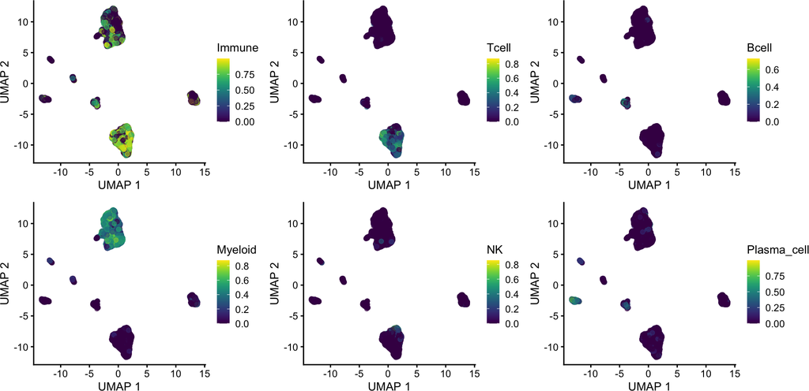

```r
pll <- lapply(names(signatures), function(x) {
    plotUMAP(sce, colour_by = x, by_exprs_values = "UCell")
})
wrap_plots(pll)
```

## 9.2 UCell + Seurat

The function `AddModuleScore_UCell()` allows operating directly on Seurat objects. UCell scores are returned as metadata columns in the Seurat object. To see how this function differs from Seurat’s own `AddModuleScore()` (not based on per-cell ranks) see [this vignette](https://carmonalab.github.io/UCell_demo/UCell_Seurat_vignette.html)

```r
library(Seurat)
seurat.object <- CreateSeuratObject(counts = exp.mat, project = "Zilionis_immune")
seurat.object <- AddModuleScore_UCell(seurat.object,
                                      features=signatures, name=NULL, ncores=4)
head(seurat.object@meta.data)
```

```
##             orig.ident nCount_RNA nFeature_RNA    Immune Tcell      Bcell
## bcHTNA Zilionis_immune       7516         2613 0.4493333     0 0.00000000
## bcHNVA Zilionis_immune       5684         1981 0.5900000     0 0.00000000
## bcALZN Zilionis_immune       4558         1867 0.6473333     0 0.00000000
## bcFWBP Zilionis_immune       2915         1308 0.4156667     0 0.08446667
## bcBJYE Zilionis_immune       3576         1548 0.9346667     0 0.00000000
## bcGSBJ Zilionis_immune       2796         1270 0.9096667     0 0.00000000
##          Myeloid NK Plasma_cell
## bcHTNA 0.5234000  0  0.00000000
## bcHNVA 0.5120000  0  0.01991667
## bcALZN 0.3593333  0  0.00000000
## bcFWBP 0.1558000  0  0.00000000
## bcBJYE 0.4639333  0  0.00000000
## bcGSBJ 0.5460000  0  0.00000000
```

Generate PCA and UMAP embeddings

```r
seurat.object <- NormalizeData(seurat.object)
seurat.object <- FindVariableFeatures(seurat.object, selection.method = "vst", nfeatures = 500)

seurat.object <- ScaleData(seurat.object)
seurat.object <- RunPCA(seurat.object, npcs = 20,
                        features=seurat.object@assays$RNA@var.features)
seurat.object <- RunUMAP(seurat.object, reduction = "pca", dims = 1:20, seed.use=123)
```

Visualize UCell scores on low-dimensional representation (UMAP)

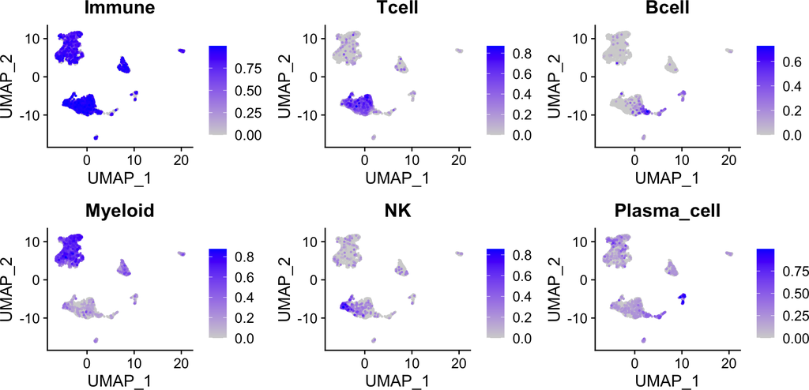

```r
FeaturePlot(seurat.object, reduction = "umap", features = names(signatures), ncol=3, order=T)
```

# 10 Resources

Please report any issues with UCell at its [GitHub repository](https://github.com/carmonalab/UCell). More demos available at [UCell demo repository](https://github.com/carmonalab/UCell_demo)

# 11 References

- Andreatta, M., Carmona, S. J. (2021) *UCell: Robust and scalable single-cell gene signature scoring* Computational and Structural Biotechnology Journal
- Zilionis, R., Engblom, C., …, Klein, A. M. (2019) *Single-Cell Transcriptomics of Human and Mouse Lung Cancers Reveals Conserved Myeloid Populations across Individuals and Species* Immunity